# Appendix for Kailing et al 2025, Mating activity and infection

Activity patterns during the mating season predict sex-biased infections in an emerging fungal disease

Macy J. Kailing, Joseph R. Hoyt, J. Paul White, Jennifer A. Redell, Heather M. Kaarakka, and Kate E. Langwig

# 1 When does activity at hibernacula during the mating season start and end for each sex? (Figure 2, Top; Models 1-2)

## 1.1 **Model 1**: First, test effect of sex on **date of first annual detection** (i.e., start of swarm).

```r
m1 = lmer(mindate2~sex + (1|site.wy2) + (1|pit_id),
              control=lmerControl(optimizer="bobyqa", optCtrl=list(maxfun=100000)),
              data = df.m1); summary(m1)
```

```
Linear mixed model fit by REML ['lmerMod']
Formula: mindate2 ~ sex + (1 | site.wy2) + (1 | pit_id)
   Data: df.m1
Control: lmerControl(optimizer = "bobyqa", optCtrl = list(maxfun = 1e+05))

REML criterion at convergence: 1119.1

Scaled residuals:
    Min      1Q  Median      3Q     Max
-3.5190 -0.5320 -0.0346  0.4860  3.9664

Random effects:
 Groups   Name        Variance Std.Dev.
 pit_id   (Intercept) 0.19965  0.4468
 site.wy2 (Intercept) 0.01754  0.1324
 Residual             0.19144  0.4375
Number of obs: 610, groups:  pit_id, 433; site.wy2, 7

Fixed effects:
            Estimate Std. Error t value
(Intercept)   1.0363     0.0599  17.301
sexF          0.2489     0.0766   3.249

Correlation of Fixed Effects:
     (Intr)
sexF -0.221
```

- *Result:* *Females start autumn activity at hibernacula later than males.*

## 1.2 **Model 2**: Then, test effect of sex on **date of last annual detection** (i.e., end of swarm).

```r
m2 = lmer(maxdate2~sex + (1|site.wy2) + (1|pit_id),
              control=lmerControl(optimizer="bobyqa", optCtrl=list(maxfun=100000)),
              data = df.m2); summary(m2)
```

```
Linear mixed model fit by REML ['lmerMod']
Formula: maxdate2 ~ sex + (1 | site.wy2) + (1 | pit_id)
   Data: df.m2
Control: lmerControl(optimizer = "bobyqa", optCtrl = list(maxfun = 1e+05))

REML criterion at convergence: 1672.9

Scaled residuals:
     Min       1Q   Median       3Q      Max
-2.90593 -0.39386  0.05173  0.51876  2.39627

Random effects:
 Groups   Name        Variance Std.Dev.
 pit_id   (Intercept) 0.15645  0.3955
 site.wy2 (Intercept) 0.07805  0.2794
 Residual             0.20263  0.4501
Number of obs: 948, groups:  pit_id, 609; site.wy2, 10

Fixed effects:
            Estimate Std. Error t value
(Intercept)  2.71097    0.09313  29.111
sexF        -0.38722    0.06159  -6.287

Correlation of Fixed Effects:
     (Intr)
sexF -0.095
```

- *Result:* *Females end autumn activity at hibernacula earlier than males.*

## 1.3 **Plot Figure 2**. Results of active period during autumn mating (Models 1-2)

- Top panel plots data and model coefficients used to determine the active period
- Bottom panel visualizes peaks in activity by sex

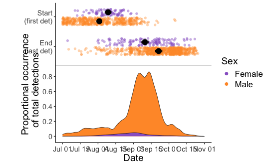

```r
print(p.fig2)
```

- **Key findings:** Females have a shorter active period, male activity fully encompasses female activity, and males remain highly active later into autumn.

# 2 What factors contribute to sex differences in activity? (Figure 3A-C, Models 3-5)

## 2.1 **Model 3, Figure 3A**: First, what are the effects of temperature and sex on **nightly activity**?

```r
# detect2: 1 = detected | 0 = undetected

m3 = glmer(detect2~bat.tavg*sex + (1|site.wy2) + (1|pit_id), family = binomial(),
            control=glmerControl(optimizer="bobyqa", optCtrl=list(maxfun=100000)),
            data = subset(df.m3)); summary(m3)
```

```
Generalized linear mixed model fit by maximum likelihood (Laplace Approximation) ['glmerMod']
 Family: binomial  ( logit )
Formula: detect2 ~ bat.tavg * sex + (1 | site.wy2) + (1 | pit_id)
   Data: subset(df.m3)
Control: glmerControl(optimizer = "bobyqa", optCtrl = list(maxfun = 1e+05))

     AIC      BIC   logLik deviance df.resid
 22769.1  22816.7 -11378.5  22757.1    20773

Scaled residuals:
    Min      1Q  Median      3Q     Max
-2.1133 -0.5959 -0.4535  0.7844  4.1081

Random effects:
 Groups   Name        Variance Std.Dev.
 pit_id   (Intercept) 0.6536   0.8085
 site.wy2 (Intercept) 0.2089   0.4571
Number of obs: 20779, groups:  pit_id, 544; site.wy2, 9

Fixed effects:
               Estimate Std. Error z value Pr(>|z|)
(Intercept)   -0.687705   0.217297  -3.165  0.00155 **
bat.tavg       0.001265   0.007507   0.169  0.86618
sexF          -3.759775   0.627498  -5.992 2.08e-09 ***
bat.tavg:sexF  0.150806   0.030333   4.972 6.64e-07 ***
---
Signif. codes:  0 ‘***’ 0.001 ‘**’ 0.01 ‘*’ 0.05 ‘.’ 0.1 ‘ ’ 1

Correlation of Fixed Effects:
            (Intr) bt.tvg sexF
bat.tavg    -0.662
sexF        -0.169  0.233
bat.tvg:sxF  0.160 -0.241 -0.980
```

```r
# view temperature slopes for each sex

kable(m3.emt)
```

| sex | bat.tavg.trend | SE | df | asymp.LCL | asymp.UCL |
| --- | --- | --- | --- | --- | --- |
| M | 0.0012651 | 0.0075070 | Inf | -0.0134483 | 0.0159784 |
| F | 0.1520707 | 0.0294381 | Inf | 0.0943731 | 0.2097683 |

- *Result:* *Females are less active generally throughout the mating period, but female activity increases with temperature. Male activity is less affected by temperature.*

## 2.2 **Model 4, Figure 3B**: Then, what are the effects of the length of the active period and sex on the **probability of being detected for the last time**?

```r
# last.det2: 1 = last day active | 0 = detected on subsequent nights
# isa: date intervals since arrival

m4 = glmer(last.det2~isa*sex + (1|site.wy2) + (1|pit_id), family=binomial(),
           control=glmerControl(optimizer="bobyqa", optCtrl=list(maxfun=100000)),
           data=subset(df.m4));summary(m4)
```

```
Generalized linear mixed model fit by maximum likelihood (Laplace Approximation) ['glmerMod']
 Family: binomial  ( logit )
Formula: last.det2 ~ isa * sex + (1 | site.wy2) + (1 | pit_id)
   Data: subset(df.m4)
Control: glmerControl(optimizer = "bobyqa", optCtrl = list(maxfun = 1e+05))

     AIC      BIC   logLik deviance df.resid
  2800.5   2839.4  -1394.3   2788.5     4787

Scaled residuals:
   Min     1Q Median     3Q    Max
-1.665 -0.300 -0.142 -0.043 74.209

Random effects:
 Groups   Name        Variance Std.Dev.
 pit_id   (Intercept) 5.469    2.339
 site.wy2 (Intercept) 1.602    1.266
Number of obs: 4793, groups:  pit_id, 433; site.wy2, 7

Fixed effects:
            Estimate Std. Error z value Pr(>|z|)
(Intercept) -4.29912    0.70400  -6.107 1.02e-09 ***
isa          0.70560    0.07336   9.618  < 2e-16 ***
sexM        -1.37247    0.52423  -2.618  0.00884 **
isa:sexM    -0.36702    0.06682  -5.492 3.97e-08 ***
---
Signif. codes:  0 ‘***’ 0.001 ‘**’ 0.01 ‘*’ 0.05 ‘.’ 0.1 ‘ ’ 1

Correlation of Fixed Effects:
         (Intr) isa    sexM
isa      -0.535
sexM     -0.603  0.501
isa:sexM  0.507 -0.950 -0.622
```

- *Result:* *Regardless of arrival date, the length of female active periods are shorter than males.*

## 2.3 **Model 5, Figure 3C**: Last, what are the effects of temperature and sex on the **probability of being detected for the last time?**

```r
# last.det2: 1 = last day active | 0 = detected on subsequent nights

m5 = glmer(last.det2~bat.tavg*sex + (1|pit_id) + (1|site.wy2), family = binomial(),
            control=glmerControl(optimizer="bobyqa", optCtrl=list(maxfun=100000)),
            data = subset(df.m5)); summary(m5)
```

```
Generalized linear mixed model fit by maximum likelihood (Laplace Approximation) ['glmerMod']
 Family: binomial  ( logit )
Formula: last.det2 ~ bat.tavg * sex + (1 | pit_id) + (1 | site.wy2)
   Data: subset(df.m5)
Control: glmerControl(optimizer = "bobyqa", optCtrl = list(maxfun = 1e+05))

     AIC      BIC   logLik deviance df.resid
  2647.9   2687.9  -1318.0   2635.9     5780

Scaled residuals:
    Min      1Q  Median      3Q     Max
-1.1904 -0.2993 -0.2391 -0.1375  9.1936

Random effects:
 Groups   Name        Variance Std.Dev.
 pit_id   (Intercept) 0.01401  0.1184
 site.wy2 (Intercept) 0.51982  0.7210
Number of obs: 5786, groups:  pit_id, 542; site.wy2, 9

Fixed effects:
              Estimate Std. Error z value Pr(>|z|)
(Intercept)    0.16202    0.56715   0.286  0.77512
bat.tavg      -0.14453    0.02669  -5.416 6.11e-08 ***
sexF           4.67270    1.54263   3.029  0.00245 **
bat.tavg:sexF -0.16407    0.07701  -2.131  0.03313 *
---
Signif. codes:  0 ‘***’ 0.001 ‘**’ 0.01 ‘*’ 0.05 ‘.’ 0.1 ‘ ’ 1

Correlation of Fixed Effects:
            (Intr) bt.tvg sexF
bat.tavg    -0.895
sexF        -0.284  0.314
bat.tvg:sxF  0.286 -0.321 -0.994
```

- *Result:* *Females end activity on warmer nights compared to males that remain active even as temperature decreases.*

## 2.4 **Plot Figure 3**. Contribution of temperature and length of swarm on sex-specific activity (Models 3-5)

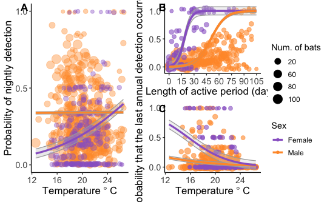

```r
print(p.fig3)
```

- **Key findings**: Female activity is generally reduced compared to males and the probability of nightly activity increases with temperature. Females also end activity fewer days after arriving at hibernacula and at higher temperatures.

# 3 How does host phenology correspond to seasonal infection intensity? (Figure 4A-B, Models 6-8)

## 3.1 **Model 6**: First, does **pathogen quantity** differ between sexes during the autumn mating season?

```r
m6 = lmer(lgdL2~sex + (1|site.wy2),
          data = df.m6); summary(m6)
```

```
Linear mixed model fit by REML ['lmerMod']
Formula: lgdL2 ~ sex + (1 | site.wy2)
   Data: df.m6

REML criterion at convergence: 314.2

Scaled residuals:
    Min      1Q  Median      3Q     Max
-1.8127 -0.5967 -0.1576  0.5203  3.5268

Random effects:
 Groups   Name        Variance Std.Dev.
 site.wy2 (Intercept) 0.2147   0.4634
 Residual             0.3193   0.5650
Number of obs: 172, groups:  site.wy2, 9

Fixed effects:
            Estimate Std. Error t value
(Intercept) -5.35210    0.17072 -31.350
sexF        -0.01397    0.09788  -0.143

Correlation of Fixed Effects:
     (Intr)
sexF -0.159
```

- *Result:* *No clear difference in pathogen loads between sexes during the autumn mating season.*

## 3.2 **Model 7, Figure 4A**: Then, how does **pathogen quantity** change seasonally by sex?

```r
m7 = lmer(lgdL2~sex*pdate2 + (1|site.wy2),
          data = df2); summary(m7)
```

```
Linear mixed model fit by REML ['lmerMod']
Formula: lgdL2 ~ sex * pdate2 + (1 | site.wy2)
   Data: df2

REML criterion at convergence: 822

Scaled residuals:
    Min      1Q  Median      3Q     Max
-2.0626 -0.6530 -0.0952  0.6261  3.5533

Random effects:
 Groups   Name        Variance Std.Dev.
 site.wy2 (Intercept) 0.2592   0.5091
 Residual             0.5722   0.7564
Number of obs: 343, groups:  site.wy2, 13

Fixed effects:
             Estimate Std. Error t value
(Intercept) -11.90983    0.69417 -17.157
sexM          3.06440    0.76088   4.027
pdate2        0.74914    0.06673  11.227
sexM:pdate2  -0.34035    0.07560  -4.502

Correlation of Fixed Effects:
            (Intr) sexM   pdate2
sexM        -0.754
pdate2      -0.971  0.776
sexM:pdate2  0.748 -0.992 -0.783
```

- *Result:* *Females develop higher pathogen loads than males by early hibernation.*

## 3.3 **Model 8, Figure 4B**: Last, does the end date of autumn activity affect **pathogen quantity in early hibernation**?

```r
m8 = lmer(lgdL2~med.maxdate + (1|site.wy2),
           control=lmerControl(optimizer="bobyqa", optCtrl=list(maxfun=100000)),
           data = df.m8); summary(m8)
```

```
Linear mixed model fit by REML ['lmerMod']
Formula: lgdL2 ~ med.maxdate + (1 | site.wy2)
   Data: df.m8
Control: lmerControl(optimizer = "bobyqa", optCtrl = list(maxfun = 1e+05))

REML criterion at convergence: 299.9

Scaled residuals:
    Min      1Q  Median      3Q     Max
-2.1009 -0.5816 -0.0953  0.6783  3.2574

Random effects:
 Groups   Name        Variance Std.Dev.
 site.wy2 (Intercept) 0.6249   0.7905
 Residual             0.6642   0.8150
Number of obs: 114, groups:  site.wy2, 10

Fixed effects:
            Estimate Std. Error t value
(Intercept)  11.1252     3.9794   2.796
med.maxdate  -1.5740     0.4071  -3.867

Correlation of Fixed Effects:
            (Intr)
med.maxdate -0.998
```

## 3.4 **Plot Figure 4**. Seasonal sex-biased pathogen quantity (Figure 4A-B; Models 7-8)

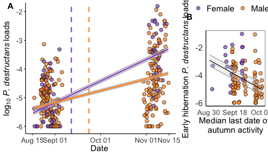

```r
print(p.fig4)
```

- **Key findings:**
  - Female-biased infection intensity only arises following the active autumn mating period.
  - Infection intensity is higher on bats associated with sites where activity ends earlier.

# 4 Supplemental analyses and figures

## 4.1 Supp Figure 1: Visualize complete dataset

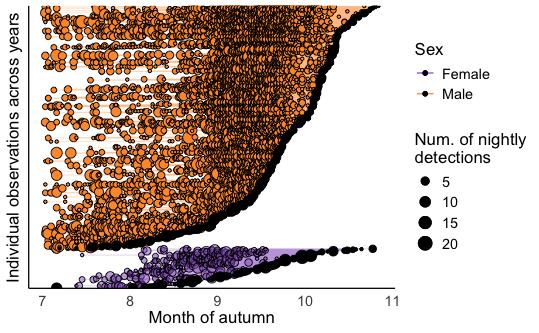

```r
print(p.sf1)
```

- Overall, males are more active than females throughout autumn and fully encompass female swarm activity.

## 4.2 Use balanced dataset to support sex-specific effects of temperature

### 4.2.1 Supp Model 1, Supp Fig 2A: Test temperature-dependence of bat activity

```r
sm1 = glmer(detect2~bat.tavg*sex + (1|site.wy2) + (1|pit_id), family = binomial(),
             control=glmerControl(optimizer="bobyqa", optCtrl=list(maxfun=100000)),
             data = subset(df1.tru)); summary(sm1)
```

```
Generalized linear mixed model fit by maximum likelihood (Laplace Approximation) ['glmerMod']
 Family: binomial  ( logit )
Formula: detect2 ~ bat.tavg * sex + (1 | site.wy2) + (1 | pit_id)
   Data: subset(df1.tru)
Control: glmerControl(optimizer = "bobyqa", optCtrl = list(maxfun = 1e+05))

     AIC      BIC   logLik deviance df.resid
  4354.4   4392.6  -2171.2   4342.4     4266

Scaled residuals:
    Min      1Q  Median      3Q     Max
-1.5418 -0.5403 -0.4081 -0.2618  4.1241

Random effects:
 Groups   Name        Variance Std.Dev.
 pit_id   (Intercept) 0.5480   0.7402
 site.wy2 (Intercept) 0.0166   0.1288
Number of obs: 4272, groups:  pit_id, 178; site.wy2, 8

Fixed effects:
              Estimate Std. Error z value Pr(>|z|)
(Intercept)   -1.19533    0.43121  -2.772  0.00557 **
bat.tavg       0.02066    0.02126   0.972  0.33107
sexF          -3.17607    0.74400  -4.269 1.96e-05 ***
bat.tavg:sexF  0.11847    0.03614   3.279  0.00104 **
---
Signif. codes:  0 ‘***’ 0.001 ‘**’ 0.01 ‘*’ 0.05 ‘.’ 0.1 ‘ ’ 1

Correlation of Fixed Effects:
            (Intr) bt.tvg sexF
bat.tavg    -0.964
sexF        -0.573  0.565
bat.tvg:sxF  0.563 -0.582 -0.980
```

```r
#view temperature slopes for each sex

kable(sm1.emt)
```

| sex | bat.tavg.trend | SE | df | asymp.LCL | asymp.UCL |
| --- | --- | --- | --- | --- | --- |
| M | 0.0206591 | 0.0212553 | Inf | -0.0210005 | 0.0623187 |
| F | 0.1391326 | 0.0293756 | Inf | 0.0815574 | 0.1967078 |

### 4.2.2 Supp Model 2, Supp Fig 2B: Differences in nightly temperature by sex and active status

```r
# detect2 (active status): 1=detected | 0=undetected

sm2 = lmer(bat.tavg~detect2*sex + (1|pit_id) + (1|site.wy2),
           data = subset(df1.tru)); summary(sm2)
```

```
Linear mixed model fit by REML ['lmerMod']
Formula: bat.tavg ~ detect2 * sex + (1 | pit_id) + (1 | site.wy2)
   Data: subset(df1.tru)

REML criterion at convergence: 19136

Scaled residuals:
    Min      1Q  Median      3Q     Max
-3.1646 -0.6908 -0.0348  0.7159  3.1546

Random effects:
 Groups   Name        Variance Std.Dev.
 pit_id   (Intercept) 0.3333   0.5773
 site.wy2 (Intercept) 1.3436   1.1591
 Residual             4.9435   2.2234
Number of obs: 4272, groups:  pit_id, 178; site.wy2, 8

Fixed effects:
              Estimate Std. Error t value
(Intercept)   19.35260    0.42333  45.715
detect21       0.13314    0.10616   1.254
sexF          -0.03922    0.12987  -0.302
detect21:sexF  0.48511    0.17724   2.737

Correlation of Fixed Effects:
            (Intr) dtct21 sexF
detect21    -0.086
sexF        -0.138  0.264
detct21:sxF  0.051 -0.600 -0.322
```

### 4.2.3 Plot Supp Figure 2. Effects of temperature with balanced observations between sexes

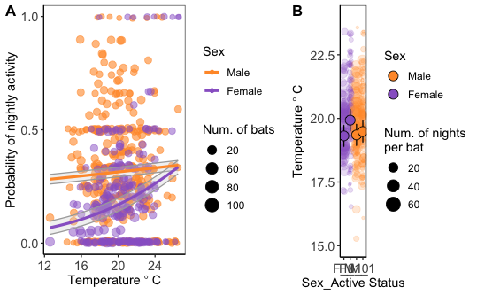

```r
print(p.sf2)
```

- *Using the balanced dataset between sexes, results are consistent with Model 3 in Figure 3A:*
  - *Female nightly activity increases with temperature, but male activity is relatively unaffected by temperature.*
  - *The difference between mean temperature on nights when bats are active compared to nights when bats are undetected is greater for females than males.*
  - *Females concentrate their activity to warmer nights, whereas males do not.*

## 4.3 Does body condition affect nightly activity (Supp Figure 3; Supp Model 3)?

### 4.3.1 Test whether temperature and mass differently influence activity between sexes

```r
sm3 <- glmmTMB(detect2~sex*mass*temp + (1|pit_id) + (1|site.wy2),
               family = binomial(),
               data = subset(df.sm3)); summary(sm3)
```

```
 Family: binomial  ( logit )
Formula:          detect2 ~ sex * mass * temp + (1 | pit_id) + (1 | site.wy2)
Data: subset(df.sm3)

     AIC      BIC   logLik deviance df.resid
  5113.5   5177.1  -2546.8   5093.5     4248

Random effects:

Conditional model:
 Groups   Name        Variance Std.Dev.
 pit_id   (Intercept) 0.6763   0.8223
 site.wy2 (Intercept) 0.2774   0.5267
Number of obs: 4258, groups:  pit_id, 336; site.wy2, 10

Conditional model:
                 Estimate Std. Error z value Pr(>|z|)
(Intercept)     -4.972624   2.307187  -2.155   0.0311 *
sexF           -18.493191   9.659752  -1.915   0.0556 .
mass             0.338061   0.257427   1.313   0.1891
temp             0.106098   0.117137   0.906   0.3651
sexF:mass        2.046204   1.164068   1.758   0.0788 .
sexF:temp        1.026604   0.485330   2.115   0.0344 *
mass:temp       -0.001248   0.013107  -0.095   0.9242
sexF:mass:temp  -0.121309   0.058665  -2.068   0.0387 *
---
Signif. codes:  0 ‘***’ 0.001 ‘**’ 0.01 ‘*’ 0.05 ‘.’ 0.1 ‘ ’ 1
```

### 4.3.2 Plot Supp Figure 3: Effects of mass, temperature and sex on nightly activity

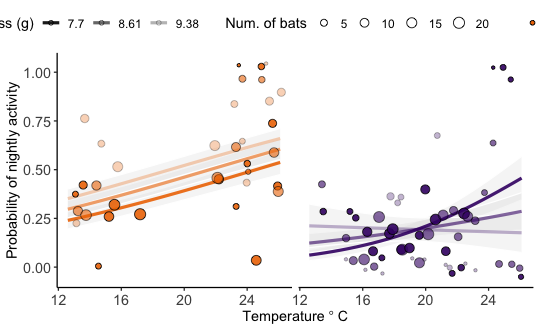

```r
print(p.sf3)
```

- *Results:*
  - *Females in lower body condition (ie body mass) concentrate activity to warm nights, but females in higher body condition do not.*
  - *Males were more active generally, but body condition did not affect the temperatures at which they were active.*
  - *Sexes are likely budgeting energy differently.*

## 4.4 Additional analysis showing association between between phenology and infection intensity (Supp Figure 4; Supp Figure 4)

### 4.4.1 Test whether median end date of autumn activity at a site influenced mean pathogen quantity in early hibernation

```r
sm4 = lmer(mean.lgdL~med.maxdate + (1|site.wy2), data = subset(df2.sum)); summary(sm4)
```

```
Linear mixed model fit by REML ['lmerMod']
Formula: mean.lgdL ~ med.maxdate + (1 | site.wy2)
   Data: subset(df2.sum)

REML criterion at convergence: 31.1

Scaled residuals:
     Min       1Q   Median       3Q      Max
-0.82223 -0.53563 -0.06433  0.47551  1.18360

Random effects:
 Groups   Name        Variance Std.Dev.
 site.wy2 (Intercept) 0.5788   0.7608
 Residual             0.1053   0.3244
Number of obs: 16, groups:  site.wy2, 10

Fixed effects:
            Estimate Std. Error t value
(Intercept)  11.0041     3.1930   3.446
med.maxdate  -1.5615     0.3285  -4.753

Correlation of Fixed Effects:
            (Intr)
med.maxdate -0.997
```

### 4.4.2 Plot Supp Figure 4. Effect of median end date of autumn activity on mean early hibernation pathogen quantity at site

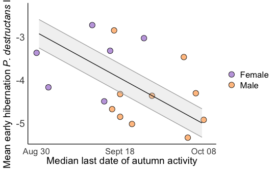

```r
print(p.sf4)
```

- *Result:* *Consistent with Figure 4B, infection intensity in early hibernation is greater at sites where autumn activity ends earlier.*

## 4.5 How many total nights are individuals active throughout the length of their active period?

### 4.5.1 Plot Supp Figure 5: Visualize cumulative number of active nights by sex

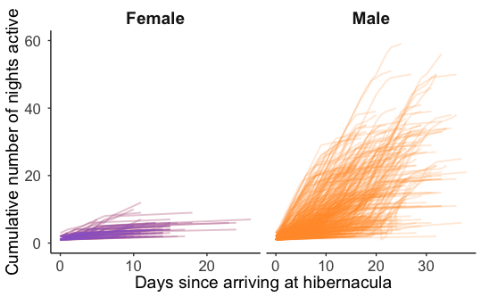

```r
print(p.sf5)
```

### 4.5.2 Calculate average number of nights detected for each sex

```r
kable(n.dates.sum)
```

| sex | mean_n.dates |
| --- | --- |
| F | 3.810526 |
| M | 13.947471 |

- Males are active for ~14 nights on average and continue activity without a clear threshold, whereas females cease activity after an average of ~4 nights.

## 4.6 Model comparisons and validation

### 4.6.1 Compare active period models as additive or interactive with site-year and sex as fixed effects (Supp Table 2)

First, begin date of activity models

```r
m1b.add = lmer(mindate2~site.wy2 + sex + (1|pit_id), data = df.m1)
m1b.int = lmer(mindate2~site.wy2 * sex + (1|pit_id), data = df.m1)
```

- Compare using AIC

```r
kable(AIC(m1b.add,m1b.int))
```

|  | df | AIC |
| --- | --- | --- |
| m1b.add | 10 | 1142.960 |
| m1b.int | 16 | 1160.287 |

Then, end date of activity models

```r
m2b.add = lmer(maxdate2~site.wy2 + sex + (1|pit_id), data = df.m2)
m2b.int = lmer(maxdate2~site.wy2 * sex + (1|pit_id), data = df.m2)
```

- Compre using AIC

```r
kable(AIC(m2b.add,m2b.int))
```

|  | df | AIC |
| --- | --- | --- |
| m2b.add | 13 | 1692.986 |
| m2b.int | 20 | 1711.309 |

- *Results*
  - *Sex is more supported as an additive rather than interactive effect in models including site-year as fixed effects.*
  - *The dates that activity starts and ends varies among sites and years, but females are consistently later to start and earlier to end compared to males.*

### 4.6.2 View results of null model comparisons and AUC estimates from k-fold cross validation of binomial models

```r
kable(nullcomps_full)
```

|  | df | AIC |
| --- | --- | --- |
| m1.null | 4 | 1134.2857 |
| m1 | 5 | 1129.1469 |
| m2.null | 4 | 1715.0409 |
| m2 | 5 | 1682.9043 |
| m3.null | 3 | 22821.9059 |
| m3 | 6 | 22769.0835 |
| m4.null | 2 | 3623.1434 |
| m4 | 6 | 2800.5278 |
| m5.null | 2 | 2741.8440 |
| m5 | 6 | 2647.9294 |
| m7.null | 3 | 966.0277 |
| m7 | 6 | 833.9688 |
| m8.null | 3 | 319.9266 |
| m8 | 4 | 307.8518 |

- All AICs of reported models are >2 scores below the null models (structured with response~1), indicating improvement over the null.

### 4.6.3 View AUC scores derived from k-fold cross validation of the logistic models reported in the main results

```r
kable(kfold_full)
```

| Model | AUC |
| --- | --- |
| m3 | 69.11% |
| m4 | 78.35% |
| m5 | 84.82% |

## 4.7 View sampling distributions used in each model by site, year and sex where applicable

**ST3A. Model 1 Sample summary: Start dates of activity**

| Year | Females | Males |
| --- | --- | --- |
| BA IT |  |  |
| 2021 | 11 | 60 |
| 2022 | 16 | 134 |
| MA N |  |  |
| 2021 | 13 | 33 |
| 2022 | 10 | 72 |
| NE MI |  |  |
| 2021 | 2 | 36 |
| 2022 | 17 | 88 |
| 2023 | 26 | 92 |

**ST3B. Model 2 Sample summary: End dates of activity**

| Year | Females | Males |
| --- | --- | --- |
| BA IT |  |  |
| 2020 | 4 | 63 |
| 2021 | 12 | 102 |
| 2022 | 17 | 139 |
| MA N |  |  |
| 2020 |  | 10 |
| 2021 | 18 | 73 |
| 2022 | 16 | 98 |
| NE MI |  |  |
| 2020 |  | 20 |
| 2021 | 7 | 73 |
| 2022 | 24 | 107 |
| 2023 | 35 | 130 |

**ST3C. Model 3 Sample summary: Prob of nightly activity**

| Year | Females | Males |
| --- | --- | --- |
| BA IT |  |  |
| 2020 | 4 | 63 |
| 2021 | 12 | 101 |
| 2022 | 17 | 139 |
| MA N |  |  |
| 2020 |  | 10 |
| 2021 | 18 | 71 |
| 2022 | 16 | 100 |
| NE MI |  |  |
| 2020 |  | 20 |
| 2021 | 7 | 73 |
| 2022 | 24 | 107 |

**ST3D. Model 4 Sample summary: Prob of last detection**

| Year | Females | Males |
| --- | --- | --- |
| BA IT |  |  |
| 2021 | 11 | 60 |
| 2022 | 16 | 134 |
| MA N |  |  |
| 2021 | 13 | 33 |
| 2022 | 10 | 73 |
| NE MI |  |  |
| 2021 | 2 | 36 |
| 2022 | 17 | 88 |
| 2023 | 26 | 92 |

**ST3E. Model 5 Sample summary: Prob of last detection**

| Year | Females | Males |
| --- | --- | --- |
| BA IT |  |  |
| 2020 | 4 | 63 |
| 2021 | 12 | 97 |
| 2022 | 17 | 139 |
| MA N |  |  |
| 2020 |  | 10 |
| 2021 | 18 | 67 |
| 2022 | 16 | 100 |
| NE MI |  |  |
| 2020 |  | 20 |
| 2021 | 6 | 72 |
| 2022 | 24 | 107 |

**ST3F. Model 7 Sample summary: Seasonal infections**

| Year | Season | Females | Males |
| --- | --- | --- | --- |
| BA IT |  |  |  |
| 2019 | Early hiber | 10 | 9 |
| 2020 | Autumn mating | 26 | 66 |
| 2020 | Early hiber | 5 | 12 |
| 2021 | Autumn mating |  | 3 |
| 2021 | Early hiber | 1 | 10 |
| 2022 | Autumn mating | 11 | 38 |
| 2022 | Early hiber | 3 | 13 |
| MA N |  |  |  |
| 2019 | Early hiber | 4 | 15 |
| 2020 | Autumn mating | 12 | 28 |
| 2020 | Early hiber | 5 | 11 |
| 2021 | Autumn mating | 14 | 12 |
| 2021 | Early hiber | 2 | 7 |
| 2022 | Autumn mating | 22 | 48 |
| 2022 | Early hiber | 4 | 9 |
| NE MI |  |  |  |
| 2019 | Early hiber | 5 | 13 |
| 2020 | Autumn mating | 5 | 37 |
| 2020 | Early hiber | 1 | 11 |
| 2021 | Autumn mating |  | 6 |
| 2021 | Early hiber | 5 | 8 |
| 2022 | Autumn mating | 23 | 34 |
| 2022 | Early hiber | 10 | 6 |
| 2023 | Early hiber |  | 20 |

**ST3G. Model 8 Sample summary: Phenology-dependent early hibernation infections**

| Year | N |
| --- | --- |
| BA IT |  |
| 2020 | 16 |
| 2021 | 8 |
| 2022 | 10 |
| MA N |  |
| 2020 | 8 |
| 2021 | 9 |
| 2022 | 10 |
| NE MI |  |
| 2020 | 7 |
| 2021 | 12 |
| 2022 | 15 |
| 2023 | 19 |